# Netop 5G Network Energy Consumption - Data Preprocessing

**Phase 1:** Data Acquisition, Inspection, Cleaning, and Feature Engineering

## Steps:

1. Load raw data from `raw_data/` directory
2. Inspect each dataset for quality issues
3. Clean data (handle missing values, invalid entries)
4. Engineer features (time-based, lagged, rolling statistics)
5. Merge datasets: CLstat + BSinfo + ECstat
6. Save processed data to `processed_data/` directory

## 1. Imports and Setup

```python
import pandas as pd
import numpy as np
import matplotlib.pyplot as plt
import seaborn as sns
from datetime import datetime
import warnings
warnings.filterwarnings('ignore')

# Set display options for better readability
pd.set_option('display.max_columns', None)
pd.set_option('display.width', None)
pd.set_option('display.max_colwidth', 50)

print("✓ Libraries imported successfully")
print(f"Pandas version: {pd.__version__}")
print(f"NumPy version: {np.__version__}")
```

```
✓ Libraries imported successfully
Pandas version: 1.1.5
NumPy version: 1.19.5
```

## 2. Data Loading

Load the three CSV files from the `raw_data/` directory.

```python
# Load the three CSV files
bsinfo = pd.read_csv('../raw_data/BSinfo.csv')
clstat = pd.read_csv('../raw_data/CLstat.csv')
ecstat = pd.read_csv('../raw_data/ECstat.csv')

print("="*80)
print("DATA LOADED SUCCESSFULLY")
print("="*80)
print(f"✓ BSinfo: {bsinfo.shape[0]:,} rows × {bsinfo.shape[1]} columns")
print(f"✓ CLstat: {clstat.shape[0]:,} rows × {clstat.shape[1]} columns")
print(f"✓ ECstat: {ecstat.shape[0]:,} rows × {ecstat.shape[1]} columns")
```

[output not shown]

## 3. Data Inspection: BSinfo (Base Station Information)

Static metadata about base stations including hardware type, TX power, bandwidth, etc.

```python
print("="*80)
print("BSinfo - Base Station Information")
print("="*80)

print("\n📊 First 5 rows:")
display(bsinfo.head())

print("\n📋 Data types:")
display(bsinfo.dtypes)

print("\n❓ Missing values:")
display(bsinfo.isnull().sum())

print("\n📈 Basic statistics:")
display(bsinfo.describe())

print("\n🔢 Unique values:")
print(f"  - Base Stations: {bsinfo['BS'].nunique()}")
print(f"  - RU Types: {bsinfo['RUType'].nunique()}")
print(f"  - Modes: {bsinfo['Mode'].nunique()}")
print(f"\n  RU Type distribution:")
display(bsinfo['RUType'].value_counts())
```

```
================================================================================
BSinfo - Base Station Information
================================================================================

📊 First 5 rows:
```

|  | BS | CellName | RUType | Mode | Frequency | Bandwidth | Antennas | TXpower |
| --- | --- | --- | --- | --- | --- | --- | --- | --- |
| 0 | B_0 | Cell0 | Type1 | Mode2 | 365.0 | 20 | 4 | 6.875934 |
| 1 | B_1 | Cell0 | Type2 | Mode2 | 532.0 | 20 | 4 | 6.875934 |
| 2 | B_2 | Cell0 | Type1 | Mode2 | 365.0 | 20 | 4 | 6.875934 |
| 3 | B_3 | Cell0 | Type2 | Mode2 | 532.0 | 20 | 4 | 6.875934 |
| 4 | B_4 | Cell0 | Type2 | Mode2 | 532.0 | 20 | 4 | 6.875934 |

```
📋 Data types:
```

```
BS            object
CellName      object
RUType        object
Mode          object
Frequency    float64
Bandwidth      int64
Antennas       int64
TXpower      float64
dtype: object
```

```
❓ Missing values:
```

```
BS           0
CellName     0
RUType       0
Mode         0
Frequency    0
Bandwidth    0
Antennas     0
TXpower      0
dtype: int64
```

```
📈 Basic statistics:
```

|  | Frequency | Bandwidth | Antennas | TXpower |
| --- | --- | --- | --- | --- |
| count | 1217.000000 | 1217.000000 | 1217.000000 | 1217.000000 |
| mean | 408.413334 | 12.706656 | 3.908792 | 6.924197 |
| std | 158.536230 | 7.397005 | 9.115707 | 0.464575 |
| min | 155.600000 | 2.000000 | 1.000000 | 5.381166 |
| 25% | 365.000000 | 8.000000 | 2.000000 | 6.576981 |
| 50% | 426.980000 | 10.000000 | 2.000000 | 6.875934 |
| 75% | 532.000000 | 20.000000 | 2.000000 | 7.325859 |
| max | 979.998000 | 20.000000 | 64.000000 | 8.375336 |

```
🔢 Unique values:
  - Base Stations: 1020
  - RU Types: 12
  - Modes: 2

  RU Type distribution:
```

```
Type1     401
Type4     231
Type6     199
Type7     116
Type5      67
Type3      49
Type11     36
Type2      35
Type9      27
Type12     22
Type10     21
Type8      13
Name: RUType, dtype: int64
```

## 4. Data Inspection: CLstat (Cell-Level Statistics)

Hourly load statistics for each cell, including traffic patterns and energy saving modes.

```python
print("="*80)
print("CLstat - Cell-Level Statistics")
print("="*80)

print("\n📊 First 5 rows:")
display(clstat.head())

print("\n📋 Data types:")
display(clstat.dtypes)

print("\n❓ Missing values:")
missing = clstat.isnull().sum()
display(missing[missing > 0])

print("\n📈 Load statistics:")
display(clstat['load'].describe())

print(f"\n📅 Date range: {clstat['Time'].min()} to {clstat['Time'].max()}")
print(f"\n🔢 Unique base stations: {clstat['BS'].nunique()}")
print(f"🔢 Unique cells: {clstat['CellName'].nunique()}")
```

```
================================================================================
CLstat - Cell-Level Statistics
================================================================================

📊 First 5 rows:
```

|  | Time | BS | CellName | load | ESMode1 | ESMode2 | ESMode3 | ESMode4 | ESMode5 | ESMode6 |
| --- | --- | --- | --- | --- | --- | --- | --- | --- | --- | --- |
| 0 | 1/1/2023 1:00 | B_0 | Cell0 | 0.487936 | 0.0 | 0.0 | 0.0 | 0 | 0.0 | 0.0 |
| 1 | 1/1/2023 2:00 | B_0 | Cell0 | 0.344468 | 0.0 | 0.0 | 0.0 | 0 | 0.0 | 0.0 |
| 2 | 1/1/2023 3:00 | B_0 | Cell0 | 0.193766 | 0.0 | 0.0 | 0.0 | 0 | 0.0 | 0.0 |
| 3 | 1/1/2023 4:00 | B_0 | Cell0 | 0.222383 | 0.0 | 0.0 | 0.0 | 0 | 0.0 | 0.0 |
| 4 | 1/1/2023 5:00 | B_0 | Cell0 | 0.175436 | 0.0 | 0.0 | 0.0 | 0 | 0.0 | 0.0 |

```
📋 Data types:
```

```
Time         object
BS           object
CellName     object
load        float64
ESMode1     float64
ESMode2     float64
ESMode3     float64
ESMode4       int64
ESMode5     float64
ESMode6     float64
dtype: object
```

```
❓ Missing values:
```

```
Series([], dtype: int64)
```

```
📈 Load statistics:
```

```
count    125575.000000
mean          0.239009
std           0.235750
min           0.000000
25%           0.055080
50%           0.153410
75%           0.352220
max           0.993957
Name: load, dtype: float64
```

```
📅 Date range: 1/1/2023 10:00 to 1/8/2023 0:00

🔢 Unique base stations: 1020
🔢 Unique cells: 4
```

## 5. Data Inspection: ECstat (Energy Consumption)

Hourly energy consumption measurements per base station.

```python
print("="*80)
print("ECstat - Energy Consumption")
print("="*80)

print("\n📊 First 5 rows:")
display(ecstat.head())

print("\n📋 Data types:")
display(ecstat.dtypes)

print("\n❓ Missing values:")
display(ecstat.isnull().sum())

print("\n📈 Energy statistics:")
display(ecstat['Energy'].describe())

print(f"\n📅 Date range: {ecstat['Time'].min()} to {ecstat['Time'].max()}")
print(f"\n🔢 Unique base stations: {ecstat['BS'].nunique()}")
print(f"🔢 Unique (Time, BS) combinations: {ecstat[['Time', 'BS']].drop_duplicates().shape[0]:,}")
```

```
================================================================================
ECstat - Energy Consumption
================================================================================

📊 First 5 rows:
```

|  | Time | BS | Energy |
| --- | --- | --- | --- |
| 0 | 1/1/2023 1:00 | B_0 | 64.275037 |
| 1 | 1/1/2023 2:00 | B_0 | 55.904335 |
| 2 | 1/1/2023 3:00 | B_0 | 57.698057 |
| 3 | 1/1/2023 4:00 | B_0 | 55.156951 |
| 4 | 1/1/2023 5:00 | B_0 | 56.053812 |

```
📋 Data types:
```

```
Time       object
BS         object
Energy    float64
dtype: object
```

```
❓ Missing values:
```

```
Time      0
BS        0
Energy    0
dtype: int64
```

```
📈 Energy statistics:
```

```
count    92629.000000
mean        28.138997
std         13.934645
min          0.747384
25%         18.236173
50%         24.065770
75%         35.724963
max        100.000000
Name: Energy, dtype: float64
```

```
📅 Date range: 1/1/2023 10:00 to 1/8/2023 0:00

🔢 Unique base stations: 923
🔢 Unique (Time, BS) combinations: 92,629
```

## 6. PRE-CLEANING ANALYSIS: Missing Value Patterns

**CRITICAL:** Before deciding on a missing value strategy, let's analyze:

1. How many missing values exist?
2. Which columns have missing values?
3. Are they random or systematic?
4. What's the temporal pattern?

This will help us choose between:

- **ffill/bfill** (current approach)
- **Time-aware interpolation** (better for time series)
- **Skip filling** (if no missing values exist)
- **Domain-specific logic** (if systematic patterns)

```python
print("="*80)
print("PRE-CLEANING INSPECTION: Missing Value Analysis")
print("="*80)

# ============================================================================
# PART 1: Overall Missing Value Counts
# ============================================================================
print("\n" + "="*80)
print("PART 1: Overall Missing Value Counts")
print("="*80)

print("\n📊 BSinfo missing values:")
missing_bs = bsinfo.isnull().sum()
if missing_bs.sum() > 0:
    display(missing_bs[missing_bs > 0])
    print(f"  Total: {missing_bs.sum()} missing values ({100*missing_bs.sum()/(bsinfo.shape[0]*bsinfo.shape[1]):.2f}% of all cells)")
else:
    print("  ✅ No missing values in BSinfo!")

print("\n📊 CLstat missing values:")
missing_cl = clstat.isnull().sum()
if missing_cl.sum() > 0:
    display(missing_cl[missing_cl > 0])
    print(f"  Total: {missing_cl.sum()} missing values ({100*missing_cl.sum()/(clstat.shape[0]*clstat.shape[1]):.2f}% of all cells)")
else:
    print("  ✅ No missing values in CLstat!")

print("\n⚡ ECstat missing values:")
missing_ec = ecstat.isnull().sum()
if missing_ec.sum() > 0:
    display(missing_ec[missing_ec > 0])
    print(f"  Total: {missing_ec.sum()} missing values ({100*missing_ec.sum()/(ecstat.shape[0]*ecstat.shape[1]):.2f}% of all cells)")
else:
    print("  ✅ No missing values in ECstat!")

# ============================================================================
# PART 2: Detailed Analysis (if missing values exist)
# ============================================================================
has_missing = (missing_cl.sum() > 0) or (missing_ec.sum() > 0)

if has_missing:
    print("\n" + "="*80)
    print("PART 2: Detailed Missing Value Analysis")
    print("="*80)

    # Analyze CLstat if it has missing values
    if missing_cl.sum() > 0:
        print("\n🔍 CLstat - Rows with missing values:")
        missing_rows = clstat[clstat.isnull().any(axis=1)]
        print(f"  Total rows affected: {len(missing_rows):,} ({100*len(missing_rows)/len(clstat):.2f}% of dataset)")
        print("\n  Sample of rows with missing values:")
        display(missing_rows.head(10))

        # Check if missing is systematic or random
        print("\n📈 Temporal pattern of missing values in CLstat:")
        clstat_temp = clstat.copy()
        clstat_temp['has_missing'] = clstat_temp.isnull().any(axis=1)
        clstat_temp['Time_parsed'] = pd.to_datetime(clstat_temp['Time'], errors='coerce')

        if clstat_temp['Time_parsed'].notna().any():
            clstat_temp['hour'] = clstat_temp['Time_parsed'].dt.hour
            clstat_temp['date'] = clstat_temp['Time_parsed'].dt.date

            # Missing by hour
            missing_by_hour = clstat_temp.groupby('hour')['has_missing'].sum()
            print("\n  Missing values by hour of day:")
            display(missing_by_hour[missing_by_hour > 0])

            # Missing by date
            missing_by_date = clstat_temp.groupby('date')['has_missing'].sum().sort_values(ascending=False)
            if len(missing_by_date) > 0:
                print("\n  Top 10 dates with most missing values:")
                display(missing_by_date.head(10))

        # Check if specific base stations/cells have more missing values
        print("\n🏢 Missing values by Base Station/Cell:")
        missing_by_bs = clstat_temp.groupby('BS')['has_missing'].sum().sort_values(ascending=False)
        if len(missing_by_bs[missing_by_bs > 0]) > 0:
            print(f"  Base stations with missing values: {(missing_by_bs > 0).sum()}")
            print("\n  Top 10 base stations with most missing values:")
            display(missing_by_bs.head(10))

    # Analyze ECstat if it has missing values
    if missing_ec.sum() > 0:
        print("\n🔍 ECstat - Rows with missing values:")
        missing_rows_ec = ecstat[ecstat.isnull().any(axis=1)]
        print(f"  Total rows affected: {len(missing_rows_ec):,} ({100*len(missing_rows_ec)/len(ecstat):.2f}% of dataset)")
        print("\n  Sample of rows with missing values:")
        display(missing_rows_ec.head(10))

# ============================================================================
# PART 3: Recommendations
# ============================================================================
print("\n" + "="*80)
print("PART 3: Missing Value Strategy Recommendation")
print("="*80)

total_missing_cl = missing_cl.sum()
total_missing_ec = missing_ec.sum()
total_missing = total_missing_cl + total_missing_ec

if total_missing == 0:
    print("\n✅ **RECOMMENDATION: SKIP MISSING VALUE HANDLING**")
    print("\n  Reason: No missing values detected in raw data!")
    print("  Action: Remove ffill/bfill lines from cleaning code.")
    print("  Note: The only NaN values will come from lagged features later.")

elif total_missing_cl / (clstat.shape[0] * clstat.shape[1]) < 0.01 and total_missing_ec / (ecstat.shape[0] * ecstat.shape[1]) < 0.01:
    print("\n✅ **RECOMMENDATION: SIMPLE FORWARD/BACKWARD FILL (ffill/bfill)**")
    print("\n  Reason: < 1% missing values, likely random gaps")
    print("  Current approach is acceptable.")
    print("  Missing values:", total_missing)

elif total_missing_cl / (clstat.shape[0] * clstat.shape[1]) < 0.05:
    print("\n⚠️  **RECOMMENDATION: TIME-AWARE INTERPOLATION**")
    print("\n  Reason: 1-5% missing values")
    print("  Better approach: Use time-based interpolation with max gap limit")
    print("  Code suggestion:")
    print("    clstat['load'] = clstat.groupby(['BS', 'CellName'])['load'].apply(")
    print("        lambda x: x.interpolate(method='linear', limit=3)")
    print("    )")

else:
    print("\n❌ **RECOMMENDATION: INVESTIGATE DATA QUALITY ISSUES**")
    print("\n  Reason: > 5% missing values - significant data quality problem")
    print("  Action: Investigate why so much data is missing before filling")
    print("  Consider: Drop problematic base stations or time periods")

print("\n" + "="*80)
print("✓ Missing value analysis complete!")
print("  Review the output above before proceeding to Cell 7 (Data Cleaning)")
print("="*80)
```

```
================================================================================
PRE-CLEANING INSPECTION: Missing Value Analysis
================================================================================

================================================================================
PART 1: Overall Missing Value Counts
================================================================================

📊 BSinfo missing values:
  ✅ No missing values in BSinfo!

📊 CLstat missing values:
  ✅ No missing values in CLstat!

⚡ ECstat missing values:
  ✅ No missing values in ECstat!

================================================================================
PART 3: Missing Value Strategy Recommendation
================================================================================

✅ **RECOMMENDATION: SKIP MISSING VALUE HANDLING**

  Reason: No missing values detected in raw data!
  Action: Remove ffill/bfill lines from cleaning code.
  Note: The only NaN values will come from lagged features later.

================================================================================
✓ Missing value analysis complete!
  Review the output above before proceeding to Cell 7 (Data Cleaning)
================================================================================
```

## 7. Data Cleaning

### Steps:

1. Convert time columns to datetime
2. Check for invalid values (negative energy, load > 1, etc.)
3. Sort data by time (needed for feature engineering)
4. Verify energy saving mode columns are present

**⚠️ IMPORTANT:** Review Cell 6 output before running this cell. Based on the analysis, no missing value handling is needed for raw data.

```python
print("="*80)
print("DATA CLEANING")
print("="*80)

# Convert time columns to datetime
print("\n⏰ Converting time columns to datetime...")
clstat['Time'] = pd.to_datetime(clstat['Time'])
ecstat['Time'] = pd.to_datetime(ecstat['Time'])
print("  ✓ Time columns converted")

# Check for invalid values
print("\n🔍 Checking for invalid values...")
issues = []
if (bsinfo['TXpower'] < 0).any():
    issues.append(f"  ⚠️  {(bsinfo['TXpower'] < 0).sum()} negative TXpower values in BSinfo")
if (clstat['load'] < 0).any() or (clstat['load'] > 1).any():
    issues.append(f"  ⚠️  {((clstat['load'] < 0) | (clstat['load'] > 1)).sum()} invalid load values in CLstat")
if (ecstat['Energy'] < 0).any():
    issues.append(f"  ⚠️  {(ecstat['Energy'] < 0).sum()} negative energy values in ECstat")

if issues:
    for issue in issues:
        print(issue)
else:
    print("  ✓ No invalid values found")

# Sort data by time (needed for feature engineering later)
print("\n📋 Sorting data by time...")
clstat = clstat.sort_values(['BS', 'CellName', 'Time'])
ecstat = ecstat.sort_values(['BS', 'Time'])
print("  ✓ Data sorted")
print(f"    CLstat: {len(clstat):,} rows")
print(f"    ECstat: {len(ecstat):,} rows")

# Keep energy saving mode columns as separate features
print("\n⚡ Energy saving mode columns...")
esmode_cols = [col for col in clstat.columns if col.startswith('ESMode')]
if esmode_cols:
    print(f"  ✓ Keeping {len(esmode_cols)} ESMode columns as separate features: {esmode_cols}")
else:
    print("  ℹ️  No energy saving mode columns found")

print("\n✓ Data cleaning complete!")
print(f"  CLstat: {len(clstat):,} rows × {clstat.shape[1]} columns")
print(f"  ECstat: {len(ecstat):,} rows × {ecstat.shape[1]} columns")
print("\n  Note: No missing value handling needed (confirmed by Cell 6)")
```

```
================================================================================
DATA CLEANING
================================================================================

⏰ Converting time columns to datetime...
  ✓ Time columns converted

🔍 Checking for invalid values...
  ✓ No invalid values found

📋 Sorting data by time...
  ✓ Data sorted
    CLstat: 125,575 rows
    ECstat: 92,629 rows

⚡ Energy saving mode columns...
  ✓ Keeping 6 ESMode columns as separate features: ['ESMode1', 'ESMode2', 'ESMode3', 'ESMode4', 'ESMode5', 'ESMode6']

✓ Data cleaning complete!
  CLstat: 125,575 rows × 10 columns
  ECstat: 92,629 rows × 3 columns

  Note: No missing value handling needed (confirmed by Cell 6)
```

## 8. Feature Engineering: Time-Based Features

Extract temporal patterns: hour of day, day of week, weekend indicator, peak hours, night time.

**Note:** `day_of_month` is excluded because the dataset only covers 7 days, which is insufficient to capture meaningful monthly patterns.

```python
print("="*80)
print("FEATURE ENGINEERING - Time-Based Features")
print("="*80)

# Time-based features for CLstat
print("\n⏰ Creating time-based features for CLstat...")
clstat['hour_of_day'] = clstat['Time'].dt.hour
clstat['day_of_week'] = clstat['Time'].dt.dayofweek
clstat['is_weekend'] = (clstat['day_of_week'] >= 5).astype(int)
clstat['is_peak_hour'] = clstat['hour_of_day'].apply(
    lambda x: 1 if (8 <= x <= 10) or (17 <= x <= 19) else 0
)
clstat['is_night_time'] = clstat['hour_of_day'].apply(
    lambda x: 1 if (22 <= x <= 23) or (0 <= x <= 6) else 0
)
print("  ✓ Created: hour_of_day, day_of_week, is_weekend, is_peak_hour, is_night_time")

# Time-based features for ECstat
print("\n⏰ Creating time-based features for ECstat...")
ecstat['hour_of_day'] = ecstat['Time'].dt.hour
ecstat['day_of_week'] = ecstat['Time'].dt.dayofweek
ecstat['is_weekend'] = (ecstat['day_of_week'] >= 5).astype(int)
ecstat['is_peak_hour'] = ecstat['hour_of_day'].apply(
    lambda x: 1 if (8 <= x <= 10) or (17 <= x <= 19) else 0
)
ecstat['is_night_time'] = ecstat['hour_of_day'].apply(
    lambda x: 1 if (22 <= x <= 23) or (0 <= x <= 6) else 0
)
print("  ✓ Created: hour_of_day, day_of_week, is_weekend, is_peak_hour, is_night_time")

print("\n✓ Time-based features complete!")
print(f"  CLstat: {clstat.shape[1]} total columns")
print(f"  ECstat: {ecstat.shape[1]} total columns")
print("\n  Note: day_of_month excluded (only 7 days of data - not meaningful for monthly patterns)")
```

```
================================================================================
FEATURE ENGINEERING - Time-Based Features
================================================================================

⏰ Creating time-based features for CLstat...
  ✓ Created: hour_of_day, day_of_week, is_weekend, is_peak_hour, is_night_time

⏰ Creating time-based features for ECstat...
  ✓ Created: hour_of_day, day_of_week, is_weekend, is_peak_hour, is_night_time

✓ Time-based features complete!
  CLstat: 15 total columns
  ECstat: 8 total columns

  Note: day_of_month excluded (only 7 days of data - not meaningful for monthly patterns)
```

```python
clstat
```

|  | Time | BS | CellName | load | ESMode1 | ESMode2 | ESMode3 | ESMode4 | ESMode5 | ESMode6 | hour_of_day | day_of_week | is_weekend | is_peak_hour | is_night_time |
| --- | --- | --- | --- | --- | --- | --- | --- | --- | --- | --- | --- | --- | --- | --- | --- |
| 0 | 2023-01-01 01:00:00 | B_0 | Cell0 | 0.487936 | 0.0 | 0.0 | 0.0 | 0 | 0.0 | 0.0 | 1 | 6 | 1 | 0 | 1 |
| 1 | 2023-01-01 02:00:00 | B_0 | Cell0 | 0.344468 | 0.0 | 0.0 | 0.0 | 0 | 0.0 | 0.0 | 2 | 6 | 1 | 0 | 1 |
| 2 | 2023-01-01 03:00:00 | B_0 | Cell0 | 0.193766 | 0.0 | 0.0 | 0.0 | 0 | 0.0 | 0.0 | 3 | 6 | 1 | 0 | 1 |
| 3 | 2023-01-01 04:00:00 | B_0 | Cell0 | 0.222383 | 0.0 | 0.0 | 0.0 | 0 | 0.0 | 0.0 | 4 | 6 | 1 | 0 | 1 |
| 4 | 2023-01-01 05:00:00 | B_0 | Cell0 | 0.175436 | 0.0 | 0.0 | 0.0 | 0 | 0.0 | 0.0 | 5 | 6 | 1 | 0 | 1 |
| ... | ... | ... | ... | ... | ... | ... | ... | ... | ... | ... | ... | ... | ... | ... | ... |
| 118283 | 2023-01-02 19:00:00 | B_999 | Cell0 | 0.077442 | 0.0 | 0.0 | 0.0 | 0 | 0.0 | 0.0 | 19 | 0 | 0 | 1 | 0 |
| 118284 | 2023-01-02 20:00:00 | B_999 | Cell0 | 0.062808 | 0.0 | 0.0 | 0.0 | 0 | 0.0 | 0.0 | 20 | 0 | 0 | 0 | 0 |
| 118285 | 2023-01-02 21:00:00 | B_999 | Cell0 | 0.062231 | 0.0 | 0.0 | 0.0 | 0 | 0.0 | 0.0 | 21 | 0 | 0 | 0 | 0 |
| 118286 | 2023-01-02 22:00:00 | B_999 | Cell0 | 0.052212 | 0.0 | 0.0 | 0.0 | 0 | 0.0 | 0.0 | 22 | 0 | 0 | 0 | 1 |
| 118287 | 2023-01-02 23:00:00 | B_999 | Cell0 | 0.050346 | 0.0 | 0.0 | 0.0 | 0 | 0.0 | 0.0 | 23 | 0 | 0 | 0 | 1 |

125575 rows × 15 columns

## 9. Feature Engineering: Lagged Features

Create features using previous time steps (t-1 and t-24 hours) for load and energy.

```python
print("="*80)
print("FEATURE ENGINEERING - Lagged Features")
print("="*80)

# Lagged features for load
print("\n📊 Creating lagged features for load...")
clstat = clstat.sort_values(['BS', 'CellName', 'Time'])
clstat['load_lag1'] = clstat.groupby(['BS', 'CellName'])['load'].shift(1)
clstat['load_lag24'] = clstat.groupby(['BS', 'CellName'])['load'].shift(24)
print("  ✓ Created: load_lag1 (t-1 hour), load_lag24 (t-24 hours)")
print(f"    NaN values in load_lag1: {clstat['load_lag1'].isnull().sum():,}")
print(f"    NaN values in load_lag24: {clstat['load_lag24'].isnull().sum():,}")

# Lagged features for energy
print("\n⚡ Creating lagged features for energy...")
ecstat = ecstat.sort_values(['BS', 'Time'])
ecstat['energy_lag1'] = ecstat.groupby('BS')['Energy'].shift(1)
ecstat['energy_lag24'] = ecstat.groupby('BS')['Energy'].shift(24)
print("  ✓ Created: energy_lag1 (t-1 hour), energy_lag24 (t-24 hours)")
print(f"    NaN values in energy_lag1: {ecstat['energy_lag1'].isnull().sum():,}")
print(f"    NaN values in energy_lag24: {ecstat['energy_lag24'].isnull().sum():,}")

print("\n✓ Lagged features complete!")
print(f"  CLstat: {clstat.shape[1]} total columns")
print(f"  ECstat: {ecstat.shape[1]} total columns")
```

```
================================================================================
FEATURE ENGINEERING - Lagged Features
================================================================================

📊 Creating lagged features for load...
  ✓ Created: load_lag1 (t-1 hour), load_lag24 (t-24 hours)
    NaN values in load_lag1: 1,217
    NaN values in load_lag24: 29,208

⚡ Creating lagged features for energy...
  ✓ Created: energy_lag1 (t-1 hour), energy_lag24 (t-24 hours)
    NaN values in energy_lag1: 923
    NaN values in energy_lag24: 21,640

✓ Lagged features complete!
  CLstat: 17 total columns
  ECstat: 10 total columns
```

## 10. Feature Engineering: Rolling Statistics

Create rolling mean and standard deviation features using 3-hour windows.

```python
print("="*80)
print("FEATURE ENGINEERING - Rolling Statistics")
print("="*80)

# Rolling statistics for load
print("\n📊 Creating rolling statistics for load (3-hour window)...")
clstat['load_rolling_mean_3h'] = clstat.groupby(['BS', 'CellName'])['load'].transform(
    lambda x: x.rolling(window=3, min_periods=1).mean()
)
clstat['load_rolling_std_3h'] = clstat.groupby(['BS', 'CellName'])['load'].transform(
    lambda x: x.rolling(window=3, min_periods=1).std()
)
print("  ✓ Created: load_rolling_mean_3h, load_rolling_std_3h")

# Rolling statistics for energy
print("\n⚡ Creating rolling statistics for energy (3-hour window)...")
ecstat['energy_rolling_mean_3h'] = ecstat.groupby('BS')['Energy'].transform(
    lambda x: x.rolling(window=3, min_periods=1).mean()
)
ecstat['energy_rolling_std_3h'] = ecstat.groupby('BS')['Energy'].transform(
    lambda x: x.rolling(window=3, min_periods=1).std()
)
print("  ✓ Created: energy_rolling_mean_3h, energy_rolling_std_3h")

print("\n✓ Rolling statistics complete!")
print(f"  CLstat: {clstat.shape[1]} total columns")
print(f"  ECstat: {ecstat.shape[1]} total columns")
```

```
================================================================================
FEATURE ENGINEERING - Rolling Statistics
================================================================================

📊 Creating rolling statistics for load (3-hour window)...
  ✓ Created: load_rolling_mean_3h, load_rolling_std_3h

⚡ Creating rolling statistics for energy (3-hour window)...
  ✓ Created: energy_rolling_mean_3h, energy_rolling_std_3h

✓ Rolling statistics complete!
  CLstat: 19 total columns
  ECstat: 12 total columns
```

## 11. Data Merging: Step 1 - CLstat + BSinfo

Merge cell-level statistics with base station metadata on `[BS, CellName]` keys.

```python
print("="*80)
print("DATA MERGING - Step 1: CLstat + BSinfo")
print("="*80)

print("\n🔗 Merging CLstat with BSinfo...")
print(f"  CLstat shape: {clstat.shape}")
print(f"  BSinfo shape: {bsinfo.shape}")
print(f"  Join keys: ['BS', 'CellName']")
print(f"  Join type: LEFT (preserve all CLstat records)")

df_merged = pd.merge(clstat, bsinfo, on=['BS', 'CellName'], how='left')

print(f"\n  ✓ Merge complete!")
print(f"    Result shape: {df_merged.shape}")
print(f"    Rows with missing values: {df_merged.isnull().any(axis=1).sum():,}")

# Show sample of merged data
print("\n📊 Sample of merged data:")
display(df_merged.head())

print("\n📋 Columns added from BSinfo:")
new_cols = [col for col in df_merged.columns if col not in clstat.columns]
print(f"  {new_cols}")
```

```
================================================================================
DATA MERGING - Step 1: CLstat + BSinfo
================================================================================

🔗 Merging CLstat with BSinfo...
  CLstat shape: (125575, 19)
  BSinfo shape: (1217, 8)
  Join keys: ['BS', 'CellName']
  Join type: LEFT (preserve all CLstat records)

  ✓ Merge complete!
    Result shape: (125575, 25)
    Rows with missing values: 29,208

📊 Sample of merged data:
```

|  | Time | BS | CellName | load | ESMode1 | ESMode2 | ESMode3 | ESMode4 | ESMode5 | ESMode6 | hour_of_day | day_of_week | is_weekend | is_peak_hour | is_night_time | load_lag1 | load_lag24 | load_rolling_mean_3h | load_rolling_std_3h | RUType | Mode | Frequency | Bandwidth | Antennas | TXpower |
| --- | --- | --- | --- | --- | --- | --- | --- | --- | --- | --- | --- | --- | --- | --- | --- | --- | --- | --- | --- | --- | --- | --- | --- | --- | --- |
| 0 | 2023-01-01 01:00:00 | B_0 | Cell0 | 0.487936 | 0.0 | 0.0 | 0.0 | 0 | 0.0 | 0.0 | 1 | 6 | 1 | 0 | 1 | NaN | NaN | 0.487936 | NaN | Type1 | Mode2 | 365.0 | 20 | 4 | 6.875934 |
| 1 | 2023-01-01 02:00:00 | B_0 | Cell0 | 0.344468 | 0.0 | 0.0 | 0.0 | 0 | 0.0 | 0.0 | 2 | 6 | 1 | 0 | 1 | 0.487936 | NaN | 0.416202 | 0.101447 | Type1 | Mode2 | 365.0 | 20 | 4 | 6.875934 |
| 2 | 2023-01-01 03:00:00 | B_0 | Cell0 | 0.193766 | 0.0 | 0.0 | 0.0 | 0 | 0.0 | 0.0 | 3 | 6 | 1 | 0 | 1 | 0.344468 | NaN | 0.342057 | 0.147100 | Type1 | Mode2 | 365.0 | 20 | 4 | 6.875934 |
| 3 | 2023-01-01 04:00:00 | B_0 | Cell0 | 0.222383 | 0.0 | 0.0 | 0.0 | 0 | 0.0 | 0.0 | 4 | 6 | 1 | 0 | 1 | 0.193766 | NaN | 0.253539 | 0.080036 | Type1 | Mode2 | 365.0 | 20 | 4 | 6.875934 |
| 4 | 2023-01-01 05:00:00 | B_0 | Cell0 | 0.175436 | 0.0 | 0.0 | 0.0 | 0 | 0.0 | 0.0 | 5 | 6 | 1 | 0 | 1 | 0.222383 | NaN | 0.197195 | 0.023661 | Type1 | Mode2 | 365.0 | 20 | 4 | 6.875934 |

```
📋 Columns added from BSinfo:
  ['RUType', 'Mode', 'Frequency', 'Bandwidth', 'Antennas', 'TXpower']
```

## 12. Data Merging: Step 2 - Result + ECstat

Merge the result with energy consumption data on `[Time, BS]` keys.

```python
print("="*80)
print("DATA MERGING - Step 2: Result + ECstat")
print("="*80)

print("\n🔗 Merging with ECstat...")
print(f"  Current shape: {df_merged.shape}")
print(f"  ECstat shape: {ecstat.shape}")
print(f"  Join keys: ['Time', 'BS']")
print(f"  Join type: LEFT (preserve all existing records)")

df_final = pd.merge(df_merged, ecstat, on=['Time', 'BS'], how='left', suffixes=('', '_ec'))

print(f"\n  ✓ Merge complete!")
print(f"    Result shape: {df_final.shape}")
print(f"    Rows with missing values: {df_final.isnull().any(axis=1).sum():,}")

# Check which columns have missing values
missing_cols = df_final.columns[df_final.isnull().any()].tolist()
if missing_cols:
    print(f"\n  ⚠️  Columns with missing values:")
    for col in missing_cols[:10]:  # Show first 10
        nan_count = df_final[col].isnull().sum()
        print(f"    - {col}: {nan_count:,} NaN ({100*nan_count/len(df_final):.1f}%)")
    if len(missing_cols) > 10:
        print(f"    ... and {len(missing_cols)-10} more columns")

# Handle duplicate columns
duplicate_cols = [col for col in df_final.columns if col.endswith('_ec') and col[:-3] in df_final.columns]
if duplicate_cols:
    print(f"\n🔧 Resolving {len(duplicate_cols)} duplicate columns...")
    for col in duplicate_cols:
        base_col = col[:-3]
        if base_col not in ['Energy']:  # Keep energy-related columns
            df_final[base_col] = df_final[base_col].fillna(df_final[col])
    df_final = df_final.drop(columns=duplicate_cols)
    print(f"  ✓ Resolved duplicate columns")

print(f"\n📊 Current shape: {df_final.shape}")
```

```
================================================================================
DATA MERGING - Step 2: Result + ECstat
================================================================================

🔗 Merging with ECstat...
  Current shape: (125575, 25)
  ECstat shape: (92629, 12)
  Join keys: ['Time', 'BS']
  Join type: LEFT (preserve all existing records)

  ✓ Merge complete!
    Result shape: (125575, 35)
    Rows with missing values: 53,006

  ⚠️  Columns with missing values:
    - load_lag1: 1,217 NaN (1.0%)
    - load_lag24: 29,208 NaN (23.3%)
    - load_rolling_std_3h: 1,217 NaN (1.0%)
    - Energy: 27,491 NaN (21.9%)
    - hour_of_day_ec: 27,491 NaN (21.9%)
    - day_of_week_ec: 27,491 NaN (21.9%)
    - is_weekend_ec: 27,491 NaN (21.9%)
    - is_peak_hour_ec: 27,491 NaN (21.9%)
    - is_night_time_ec: 27,491 NaN (21.9%)
    - energy_lag1: 28,433 NaN (22.6%)
    ... and 3 more columns

🔧 Resolving 5 duplicate columns...
  ✓ Resolved duplicate columns

📊 Current shape: (125575, 30)
```

## 13. Final Cleanup: Remove Rows with Missing Values

Remove rows that have missing values after the merge (unmatched records and lag features).

```python
print("="*80)
print("FINAL CLEANUP")
print("="*80)

print("\n🧹 Removing rows with missing values...")
rows_before = len(df_final)
print(f"  Rows before dropna(): {rows_before:,}")
print(f"  Rows with NaN: {df_final.isnull().any(axis=1).sum():,}")

df_final = df_final.dropna()

rows_removed = rows_before - len(df_final)
print(f"\n  ✓ Cleanup complete!")
print(f"    Rows removed: {rows_removed:,} ({100*rows_removed/rows_before:.1f}%)")
print(f"    Rows retained: {len(df_final):,} ({100*len(df_final)/rows_before:.1f}%)")

print(f"\n📊 Final dataset shape: {df_final.shape[0]:,} rows × {df_final.shape[1]} columns")
print(f"\n🎯 Data quality check:")
print(f"  Missing values: {df_final.isnull().sum().sum()}")
print(f"  Duplicate rows: {df_final.duplicated().sum()}")
```

```
================================================================================
FINAL CLEANUP
================================================================================

🧹 Removing rows with missing values...
  Rows before dropna(): 125,575
  Rows with NaN: 53,006

  ✓ Cleanup complete!
    Rows removed: 53,006 (42.2%)
    Rows retained: 72,569 (57.8%)

📊 Final dataset shape: 72,569 rows × 30 columns

🎯 Data quality check:
  Missing values: 0
  Duplicate rows: 0
```

```python
print("="*80)
print("SAVING PROCESSED DATA - Multiple Variants")
print("="*80)

# =============================================================================
# Define feature sets for each variant
# =============================================================================

# Variant 1: Baseline - Raw features only
baseline_features = [
    'Time', 'BS', 'CellName', 'load',
    'ESMode1', 'ESMode2', 'ESMode3', 'ESMode4', 'ESMode5', 'ESMode6',
    'RUType', 'Mode', 'Frequency', 'Bandwidth', 'Antennas', 'TXpower',
    'Energy'
]

# Variant 2: Time - Raw + time features
time_features = baseline_features + [
    'hour_of_day', 'day_of_week', 'is_weekend', 'is_peak_hour', 'is_night_time'
]

# Variant 3: Full - Everything (raw + time + lag + rolling)
lag_rolling_features = [
    'load_lag1', 'load_lag24', 'energy_lag1', 'energy_lag24',
    'load_rolling_mean_3h', 'load_rolling_std_3h',
    'energy_rolling_mean_3h', 'energy_rolling_std_3h'
]
full_features = time_features + lag_rolling_features

# =============================================================================
# Verify all columns exist in df_final
# =============================================================================
print("\n🔍 Verifying column availability...")
missing_baseline = [col for col in baseline_features if col not in df_final.columns]
missing_time = [col for col in time_features if col not in df_final.columns]
missing_full = [col for col in full_features if col not in df_final.columns]

if missing_baseline:
    print(f"  ⚠️  Missing in baseline: {missing_baseline}")
if missing_time:
    print(f"  ⚠️  Missing in time: {missing_time}")
if missing_full:
    print(f"  ⚠️  Missing in full: {missing_full}")

if not (missing_baseline or missing_time or missing_full):
    print("  ✓ All required columns present!")

# =============================================================================
# Save Variant 1: Baseline (Raw features only)
# =============================================================================
print("\n💾 Saving Variant 1: netop_ml_baseline.csv...")
df_baseline = df_final[baseline_features].copy()
df_baseline.to_csv('../processed_data/netop_ml_baseline.csv', index=False)
print(f"  ✓ Saved: {df_baseline.shape[0]:,} rows × {df_baseline.shape[1]} columns")
print(f"  Features: Raw features only (no time, no lag, no rolling)")

# =============================================================================
# Save Variant 2: Time (Raw + time features)
# =============================================================================
print("\n💾 Saving Variant 2: netop_ml_time.csv...")
df_time = df_final[time_features].copy()
df_time.to_csv('../processed_data/netop_ml_time.csv', index=False)
print(f"  ✓ Saved: {df_time.shape[0]:,} rows × {df_time.shape[1]} columns")
print(f"  Features: Raw + time features (no lag, no rolling)")

# =============================================================================
# Save Variant 3: Full (Everything)
# =============================================================================
print("\n💾 Saving Variant 3: netop_ml_full.csv...")
df_full = df_final[full_features].copy()
df_full.to_csv('../processed_data/netop_ml_full.csv', index=False)
print(f"  ✓ Saved: {df_full.shape[0]:,} rows × {df_full.shape[1]} columns")
print(f"  Features: Raw + time + lag + rolling features")

# =============================================================================
# Summary
# =============================================================================
print("\n" + "="*80)
print("SUMMARY - Files Created")
print("="*80)
print(f"""
📁 processed_data/
  ├── netop_ml_baseline.csv    {df_baseline.shape[0]:>6,} rows × {df_baseline.shape[1]:>2} cols  (Raw only)
  ├── netop_ml_time.csv         {df_time.shape[0]:>6,} rows × {df_time.shape[1]:>2} cols  (Raw + Time)
  └── netop_ml_full.csv         {df_full.shape[0]:>6,} rows × {df_full.shape[1]:>2} cols  (Full features)
""")

print("✓ All files saved successfully!")
print("✓ Ready for Phase 2: Traditional ML experiments")
print("="*80)
```

[output not shown]

## 15. Summary Report

Final statistics and summary of the preprocessing pipeline.

```python
print("="*80)
print("PREPROCESSING SUMMARY")
print("="*80)

print(f"\n📊 Final Dataset Shape: {df_final.shape[0]:,} rows × {df_final.shape[1]} columns")

print("\n📋 All Columns:")
for i, col in enumerate(df_final.columns, 1):
    print(f"  {i:2d}. {col}")

print("\n🎯 Data Quality:")
print(f"  - Missing values: {df_final.isnull().sum().sum()}")
print(f"  - Duplicate rows: {df_final.duplicated().sum()}")
print(f"  - Date range: {df_final['Time'].min()} to {df_final['Time'].max()}")
print(f"  - Number of base stations: {df_final['BS'].nunique()}")
print(f"  - Number of cells: {df_final['CellName'].nunique()}")
print(f"  - Total measurements: {len(df_final):,}")

print("\n📈 Key Statistics:")
display(df_final[['load', 'Energy', 'TXpower', 'Bandwidth']].describe())

# Show ESMode statistics if available
esmode_cols = [col for col in df_final.columns if col.startswith('ESMode')]
if esmode_cols:
    print("\n⚡ Energy Saving Mode Statistics:")
    print(f"  Found {len(esmode_cols)} ESMode columns: {esmode_cols}")
    for col in esmode_cols:
        active_pct = 100 * (df_final[col] > 0).mean()
        if active_pct > 0:
            print(f"  - {col}: Active {active_pct:.2f}% of the time")

print("\n" + "="*80)
print("✓ PREPROCESSING COMPLETE!")
print("="*80)
```

```
================================================================================
PREPROCESSING SUMMARY
================================================================================

📊 Final Dataset Shape: 72,569 rows × 30 columns

📋 All Columns:
   1. Time
   2. BS
   3. CellName
   4. load
   5. ESMode1
   6. ESMode2
   7. ESMode3
   8. ESMode4
   9. ESMode5
  10. ESMode6
  11. hour_of_day
  12. day_of_week
  13. is_weekend
  14. is_peak_hour
  15. is_night_time
  16. load_lag1
  17. load_lag24
  18. load_rolling_mean_3h
  19. load_rolling_std_3h
  20. RUType
  21. Mode
  22. Frequency
  23. Bandwidth
  24. Antennas
  25. TXpower
  26. Energy
  27. energy_lag1
  28. energy_lag24
  29. energy_rolling_mean_3h
  30. energy_rolling_std_3h

🎯 Data Quality:
  - Missing values: 0
  - Duplicate rows: 0
  - Date range: 2023-01-02 01:00:00 to 2023-01-08 00:00:00
  - Number of base stations: 816
  - Number of cells: 2
  - Total measurements: 72,569

📈 Key Statistics:
```

|  | load | Energy | TXpower | Bandwidth |
| --- | --- | --- | --- | --- |
| count | 72569.000000 | 72569.000000 | 72569.000000 | 72569.000000 |
| mean | 0.255366 | 28.636431 | 6.696789 | 16.738897 |
| std | 0.242809 | 13.930932 | 0.259494 | 4.765428 |
| min | 0.000000 | 3.587444 | 5.381166 | 5.000000 |
| 25% | 0.058930 | 18.535127 | 6.427504 | 10.000000 |
| 50% | 0.173790 | 24.663677 | 6.875934 | 20.000000 |
| 75% | 0.382500 | 36.472347 | 6.875934 | 20.000000 |
| max | 0.993957 | 100.000000 | 6.980568 | 20.000000 |

```
⚡ Energy Saving Mode Statistics:
  Found 6 ESMode columns: ['ESMode1', 'ESMode2', 'ESMode3', 'ESMode4', 'ESMode5', 'ESMode6']
  - ESMode1: Active 4.46% of the time
  - ESMode2: Active 4.74% of the time
  - ESMode3: Active 0.23% of the time
  - ESMode5: Active 0.00% of the time

================================================================================
✓ PREPROCESSING COMPLETE!
================================================================================
```

## 16. Data Visualization

Comprehensive visualizations showing how each feature (raw and engineered) impacts Energy consumption (target variable).

```
================================================================================
DATA VISUALIZATION - Energy Consumption Analysis
================================================================================
```

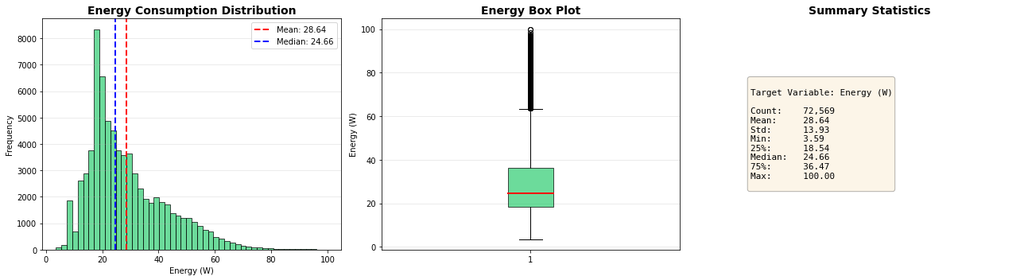

```
✓ Section 1: Target variable distribution visualized
```

```python
# =============================================================================
# 1. TARGET VARIABLE DISTRIBUTION
# =============================================================================
print("="*80)
print("DATA VISUALIZATION - Energy Consumption Analysis")
print("="*80)

fig, axes = plt.subplots(1, 3, figsize=(18, 5))

# Energy distribution
axes[0].hist(df_final['Energy'], bins=50, color='#2ecc71', alpha=0.7, edgecolor='black')
axes[0].axvline(df_final['Energy'].mean(), color='red', linestyle='--', linewidth=2,
                label=f'Mean: {df_final["Energy"].mean():.2f}')
axes[0].axvline(df_final['Energy'].median(), color='blue', linestyle='--', linewidth=2,
                label=f'Median: {df_final["Energy"].median():.2f}')
axes[0].set_title('Energy Consumption Distribution', fontsize=14, fontweight='bold')
axes[0].set_xlabel('Energy (W)')
axes[0].set_ylabel('Frequency')
axes[0].legend()
axes[0].grid(True, alpha=0.3, axis='y')

# Box plot
axes[1].boxplot(df_final['Energy'], patch_artist=True,
                boxprops=dict(facecolor='#2ecc71', alpha=0.7),
                medianprops=dict(color='red', linewidth=2))
axes[1].set_title('Energy Box Plot', fontsize=14, fontweight='bold')
axes[1].set_ylabel('Energy (W)')
axes[1].grid(True, alpha=0.3, axis='y')

# Summary statistics
stats_text = f"""
Target Variable: Energy (W)

Count:    {df_final['Energy'].count():,}
Mean:     {df_final['Energy'].mean():.2f}
Std:      {df_final['Energy'].std():.2f}
Min:      {df_final['Energy'].min():.2f}
25%:      {df_final['Energy'].quantile(0.25):.2f}
Median:   {df_final['Energy'].median():.2f}
75%:      {df_final['Energy'].quantile(0.75):.2f}
Max:      {df_final['Energy'].max():.2f}
"""
axes[2].text(0.1, 0.5, stats_text, fontsize=11, family='monospace',
             verticalalignment='center', bbox=dict(boxstyle='round', facecolor='wheat', alpha=0.3))
axes[2].axis('off')
axes[2].set_title('Summary Statistics', fontsize=14, fontweight='bold')

plt.tight_layout()
plt.show()

print("\n✓ Section 1: Target variable distribution visualized")
```

```
[2/8] Numerical Features vs Energy...
```

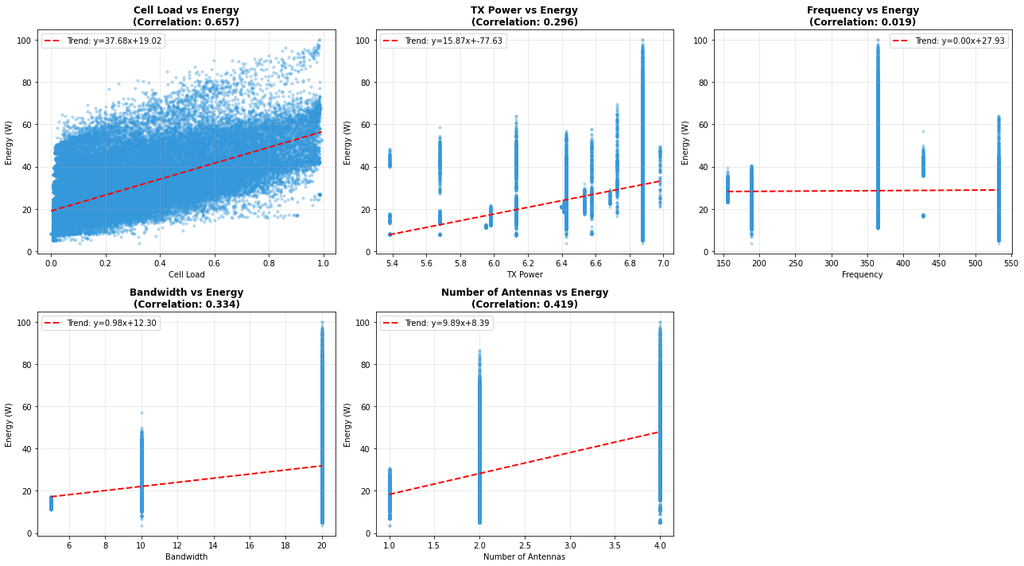

```
  ✓ Numerical features visualized
```

```python
# =============================================================================
# 2. NUMERICAL FEATURES VS ENERGY
# =============================================================================
print("\n[2/8] Numerical Features vs Energy...")

# Numerical features to analyze
numerical_features = {
    'load': 'Cell Load',
    'TXpower': 'TX Power',
    'Frequency': 'Frequency',
    'Bandwidth': 'Bandwidth',
    'Antennas': 'Number of Antennas'
}

fig, axes = plt.subplots(2, 3, figsize=(18, 10))
axes = axes.flatten()

for idx, (feature, title) in enumerate(numerical_features.items()):
    # Scatter plot with regression line
    axes[idx].scatter(df_final[feature], df_final['Energy'], alpha=0.3, s=10, color='#3498db')

    # Add trend line
    z = np.polyfit(df_final[feature], df_final['Energy'], 1)
    p = np.poly1d(z)
    axes[idx].plot(df_final[feature].sort_values(), p(df_final[feature].sort_values()),
                   "r--", linewidth=2, label=f'Trend: y={z[0]:.2f}x+{z[1]:.2f}')

    # Calculate correlation
    corr = df_final[[feature, 'Energy']].corr().iloc[0, 1]

    axes[idx].set_title(f'{title} vs Energy\n(Correlation: {corr:.3f})', fontsize=12, fontweight='bold')
    axes[idx].set_xlabel(title)
    axes[idx].set_ylabel('Energy (W)')
    axes[idx].legend()
    axes[idx].grid(True, alpha=0.3)

# Remove extra subplot
axes[-1].remove()

plt.tight_layout()
plt.show()

print("  ✓ Numerical features visualized")
```

```
[3/8] Categorical Features vs Energy...
```

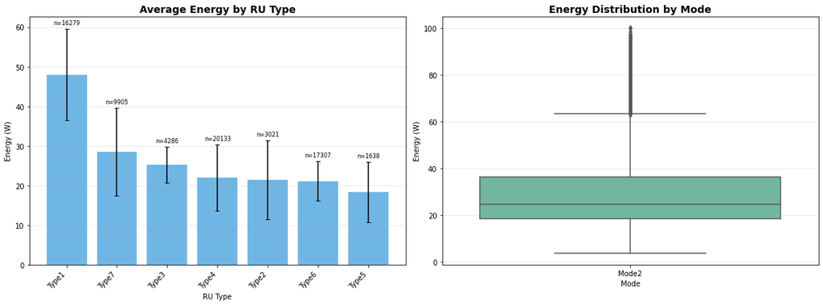

```
  ✓ Categorical features visualized
```

```python
# =============================================================================
# 3. CATEGORICAL FEATURES VS ENERGY
# =============================================================================
print("\n[3/8] Categorical Features vs Energy...")

fig, axes = plt.subplots(1, 2, figsize=(16, 6))

# RUType vs Energy
rutype_stats = df_final.groupby('RUType')['Energy'].agg(['mean', 'std', 'count'])
rutype_stats = rutype_stats.sort_values('mean', ascending=False)

axes[0].bar(range(len(rutype_stats)), rutype_stats['mean'],
            yerr=rutype_stats['std'], capsize=3, color='#3498db', alpha=0.7)
axes[0].set_title('Average Energy by RU Type', fontsize=14, fontweight='bold')
axes[0].set_xlabel('RU Type')
axes[0].set_ylabel('Energy (W)')
axes[0].set_xticks(range(len(rutype_stats)))
axes[0].set_xticklabels(rutype_stats.index, rotation=45, ha='right')
axes[0].grid(True, alpha=0.3, axis='y')

# Add count labels
for i, count in enumerate(rutype_stats['count']):
    axes[0].text(i, rutype_stats['mean'].iloc[i] + rutype_stats['std'].iloc[i] + 1,
                f'n={count}', ha='center', fontsize=8)

# Mode vs Energy
sns.boxplot(data=df_final, x='Mode', y='Energy', ax=axes[1], palette='Set2')
axes[1].set_title('Energy Distribution by Mode', fontsize=14, fontweight='bold')
axes[1].set_ylabel('Energy (W)')
axes[1].grid(True, alpha=0.3, axis='y')

plt.tight_layout()
plt.show()

print("  ✓ Categorical features visualized")
```

```
[4/8] Energy Saving Modes vs Energy...
```

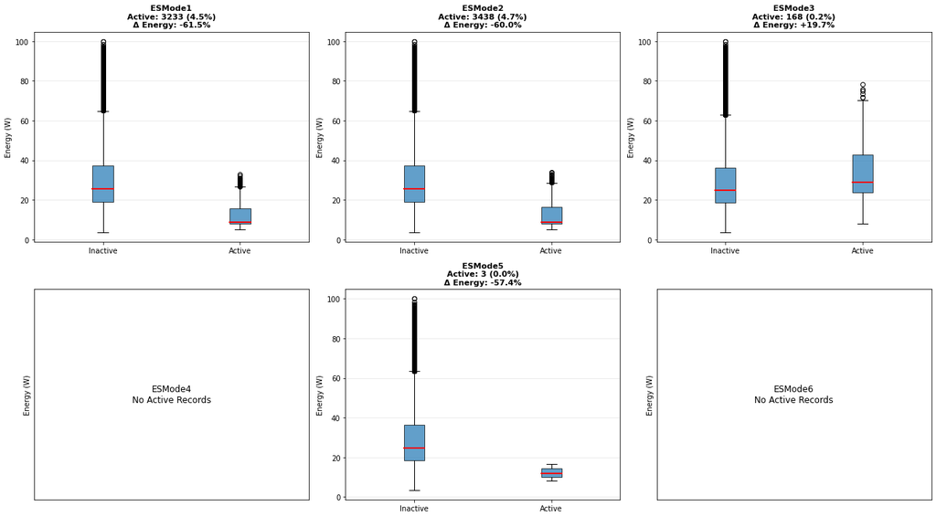

```
  ✓ Energy saving modes visualized
```

```python
# =============================================================================
# 4. ENERGY SAVING MODES VS ENERGY
# =============================================================================
print("\n[4/8] Energy Saving Modes vs Energy...")

esmode_cols = [col for col in df_final.columns if col.startswith('ESMode')]

fig, axes = plt.subplots(2, 3, figsize=(18, 10))
axes = axes.flatten()

for idx, esmode in enumerate(esmode_cols):
    # Separate active vs inactive
    active = df_final[df_final[esmode] > 0]
    inactive = df_final[df_final[esmode] == 0]

    if len(active) > 0:
        # Box plot comparison
        data_to_plot = [inactive['Energy'], active['Energy']]
        axes[idx].boxplot(data_to_plot, labels=['Inactive', 'Active'],
                         patch_artist=True,
                         boxprops=dict(alpha=0.7),
                         medianprops=dict(color='red', linewidth=2))

        # Add mean comparison
        mean_inactive = inactive['Energy'].mean()
        mean_active = active['Energy'].mean()
        diff = ((mean_active - mean_inactive) / mean_inactive * 100)

        axes[idx].set_title(f'{esmode}\nActive: {len(active)} ({100*len(active)/len(df_final):.1f}%)\nΔ Energy: {diff:+.1f}%',
                          fontsize=11, fontweight='bold')
    else:
        axes[idx].text(0.5, 0.5, f'{esmode}\nNo Active Records',
                      ha='center', va='center', fontsize=12)
        axes[idx].set_xticks([])
        axes[idx].set_yticks([])

    axes[idx].set_ylabel('Energy (W)')
    axes[idx].grid(True, alpha=0.3, axis='y')

plt.tight_layout()
plt.show()

print("  ✓ Energy saving modes visualized")
```

```
[5/8] Temporal Patterns...
```

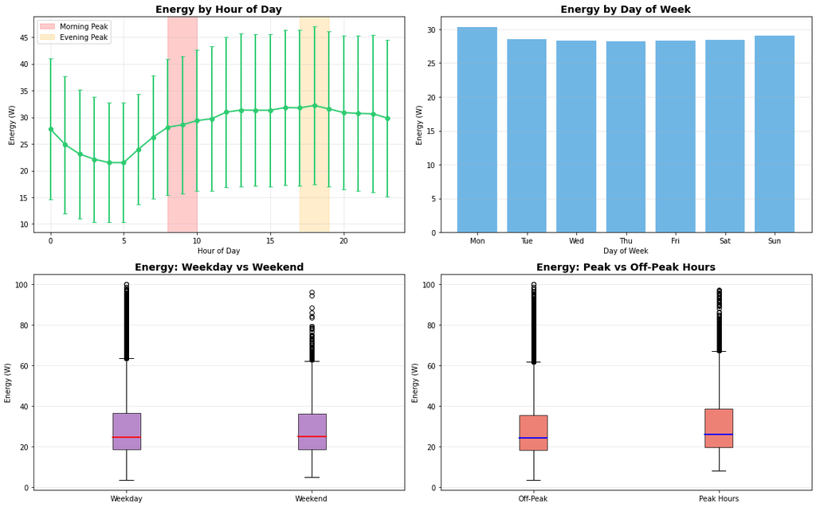

```
  ✓ Temporal patterns visualized
```

```python
# =============================================================================
# 5. TEMPORAL PATTERNS
# =============================================================================
print("\n[5/8] Temporal Patterns...")

fig, axes = plt.subplots(2, 2, figsize=(16, 10))

# Energy by hour of day
hourly_energy = df_final.groupby('hour_of_day')['Energy'].agg(['mean', 'std'])
axes[0, 0].errorbar(hourly_energy.index, hourly_energy['mean'],
                    yerr=hourly_energy['std'], marker='o', capsize=3,
                    linewidth=2, markersize=6, color='#2ecc71')
axes[0, 0].axvspan(8, 10, alpha=0.2, color='red', label='Morning Peak')
axes[0, 0].axvspan(17, 19, alpha=0.2, color='orange', label='Evening Peak')
axes[0, 0].set_title('Energy by Hour of Day', fontsize=14, fontweight='bold')
axes[0, 0].set_xlabel('Hour of Day')
axes[0, 0].set_ylabel('Energy (W)')
axes[0, 0].legend()
axes[0, 0].grid(True, alpha=0.3)

# Energy by day of week
dow_labels = ['Mon', 'Tue', 'Wed', 'Thu', 'Fri', 'Sat', 'Sun']
dow_energy = df_final.groupby('day_of_week')['Energy'].mean()
axes[0, 1].bar(dow_energy.index, dow_energy.values, color='#3498db', alpha=0.7)
axes[0, 1].set_title('Energy by Day of Week', fontsize=14, fontweight='bold')
axes[0, 1].set_xlabel('Day of Week')
axes[0, 1].set_ylabel('Energy (W)')
axes[0, 1].set_xticks(range(7))
axes[0, 1].set_xticklabels(dow_labels)
axes[0, 1].grid(True, alpha=0.3, axis='y')

# Weekend vs Weekday
weekend_comp = df_final.groupby('is_weekend')['Energy'].apply(list)
axes[1, 0].boxplot([weekend_comp[0], weekend_comp[1]],
                    labels=['Weekday', 'Weekend'],
                    patch_artist=True,
                    boxprops=dict(facecolor='#9b59b6', alpha=0.7),
                    medianprops=dict(color='red', linewidth=2))
axes[1, 0].set_title('Energy: Weekday vs Weekend', fontsize=14, fontweight='bold')
axes[1, 0].set_ylabel('Energy (W)')
axes[1, 0].grid(True, alpha=0.3, axis='y')

# Peak vs Off-peak
peak_comp = df_final.groupby('is_peak_hour')['Energy'].apply(list)
axes[1, 1].boxplot([peak_comp[0], peak_comp[1]],
                    labels=['Off-Peak', 'Peak Hours'],
                    patch_artist=True,
                    boxprops=dict(facecolor='#e74c3c', alpha=0.7),
                    medianprops=dict(color='blue', linewidth=2))
axes[1, 1].set_title('Energy: Peak vs Off-Peak Hours', fontsize=14, fontweight='bold')
axes[1, 1].set_ylabel('Energy (W)')
axes[1, 1].grid(True, alpha=0.3, axis='y')

plt.tight_layout()
plt.show()

print("  ✓ Temporal patterns visualized")
```

```
[6/8] Lagged Features vs Energy...
```

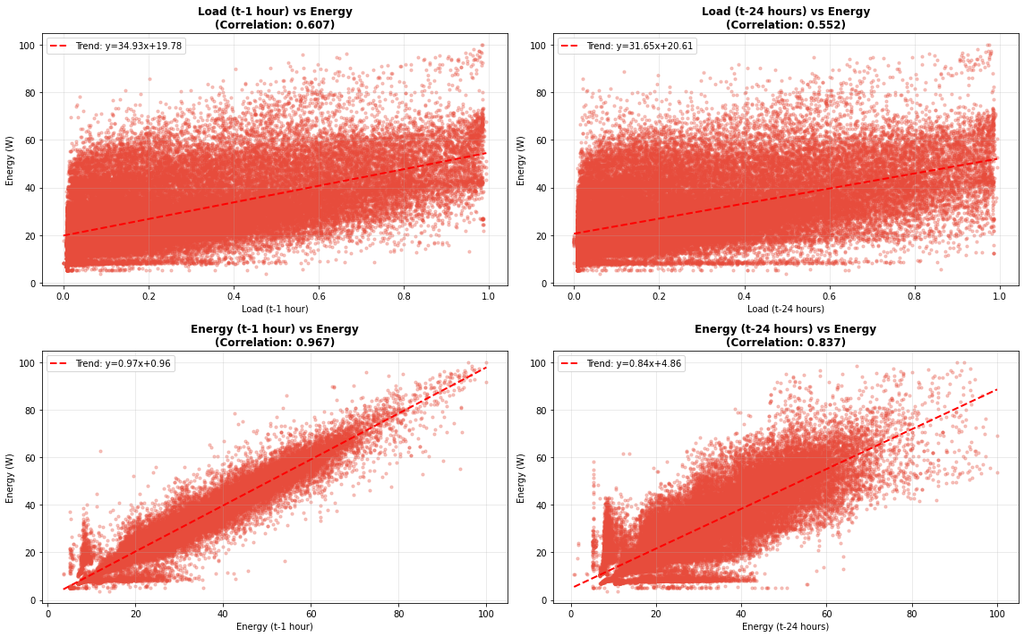

```
  ✓ Lagged features visualized
```

```python
# =============================================================================
# 6. LAGGED FEATURES VS ENERGY
# =============================================================================
print("\n[6/8] Lagged Features vs Energy...")

lag_features = {
    'load_lag1': 'Load (t-1 hour)',
    'load_lag24': 'Load (t-24 hours)',
    'energy_lag1': 'Energy (t-1 hour)',
    'energy_lag24': 'Energy (t-24 hours)'
}

fig, axes = plt.subplots(2, 2, figsize=(16, 10))
axes = axes.flatten()

for idx, (feature, title) in enumerate(lag_features.items()):
    # Scatter plot
    axes[idx].scatter(df_final[feature], df_final['Energy'],
                     alpha=0.3, s=10, color='#e74c3c')

    # Trend line
    valid_data = df_final[[feature, 'Energy']].dropna()
    if len(valid_data) > 0:
        z = np.polyfit(valid_data[feature], valid_data['Energy'], 1)
        p = np.poly1d(z)
        axes[idx].plot(valid_data[feature].sort_values(),
                      p(valid_data[feature].sort_values()),
                      "r--", linewidth=2, label=f'Trend: y={z[0]:.2f}x+{z[1]:.2f}')

        # Correlation
        corr = valid_data[[feature, 'Energy']].corr().iloc[0, 1]
        axes[idx].set_title(f'{title} vs Energy\n(Correlation: {corr:.3f})',
                          fontsize=12, fontweight='bold')

    axes[idx].set_xlabel(title)
    axes[idx].set_ylabel('Energy (W)')
    axes[idx].legend()
    axes[idx].grid(True, alpha=0.3)

plt.tight_layout()
plt.show()

print("  ✓ Lagged features visualized")
```

```
[7/8] Rolling Statistics vs Energy...
```

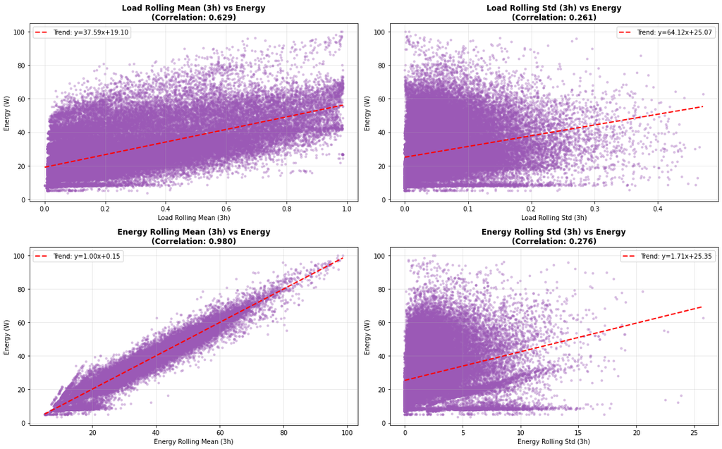

```
  ✓ Rolling statistics visualized
```

```python
# =============================================================================
# 7. ROLLING STATISTICS VS ENERGY
# =============================================================================
print("\n[7/8] Rolling Statistics vs Energy...")

rolling_features = {
    'load_rolling_mean_3h': 'Load Rolling Mean (3h)',
    'load_rolling_std_3h': 'Load Rolling Std (3h)',
    'energy_rolling_mean_3h': 'Energy Rolling Mean (3h)',
    'energy_rolling_std_3h': 'Energy Rolling Std (3h)'
}

fig, axes = plt.subplots(2, 2, figsize=(16, 10))
axes = axes.flatten()

for idx, (feature, title) in enumerate(rolling_features.items()):
    # Scatter plot
    axes[idx].scatter(df_final[feature], df_final['Energy'],
                     alpha=0.3, s=10, color='#9b59b6')

    # Trend line
    valid_data = df_final[[feature, 'Energy']].dropna()
    if len(valid_data) > 0:
        z = np.polyfit(valid_data[feature], valid_data['Energy'], 1)
        p = np.poly1d(z)
        axes[idx].plot(valid_data[feature].sort_values(),
                      p(valid_data[feature].sort_values()),
                      "r--", linewidth=2, label=f'Trend: y={z[0]:.2f}x+{z[1]:.2f}')

        # Correlation
        corr = valid_data[[feature, 'Energy']].corr().iloc[0, 1]
        axes[idx].set_title(f'{title} vs Energy\n(Correlation: {corr:.3f})',
                          fontsize=12, fontweight='bold')

    axes[idx].set_xlabel(title)
    axes[idx].set_ylabel('Energy (W)')
    axes[idx].legend()
    axes[idx].grid(True, alpha=0.3)

plt.tight_layout()
plt.show()

print("  ✓ Rolling statistics visualized")
```

```
[8/8] Correlation Analysis & Feature Importance...
```

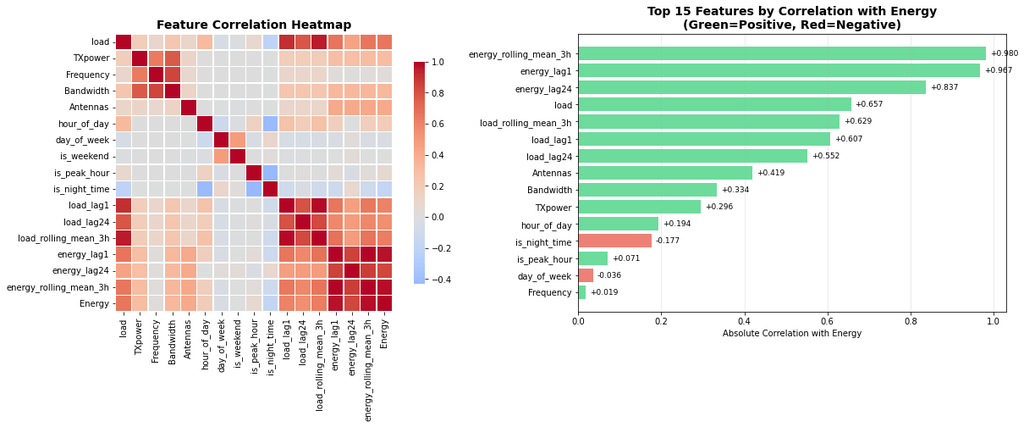

```
  ✓ Correlation heatmap and feature importance visualized

================================================================================
✓ DATA VISUALIZATION COMPLETE!
================================================================================

Key Insights Summary:
  • Total features analyzed: 27 (excluding Time, BS, CellName)
  • Target variable: Energy (W)
  • Top 3 correlated features with Energy:
    1. energy_rolling_mean_3h: +0.980
    2. energy_lag1: +0.967
    3. energy_lag24: +0.837

  All visualizations cover feature relationships with Energy consumption
```

```python
# =============================================================================
# 8. CORRELATION HEATMAP & FEATURE IMPORTANCE PREVIEW
# =============================================================================
print("\n[8/8] Correlation Analysis & Feature Importance...")

fig, axes = plt.subplots(1, 2, figsize=(18, 7))

# Select numerical features for correlation
numerical_cols = ['load', 'TXpower', 'Frequency', 'Bandwidth', 'Antennas',
                  'hour_of_day', 'day_of_week', 'is_weekend', 'is_peak_hour', 'is_night_time',
                  'load_lag1', 'load_lag24', 'load_rolling_mean_3h',
                  'energy_lag1', 'energy_lag24', 'energy_rolling_mean_3h',
                  'Energy']

# Correlation matrix
corr_matrix = df_final[numerical_cols].corr()

# Heatmap
sns.heatmap(corr_matrix, annot=False, cmap='coolwarm', center=0,
            square=True, linewidths=0.5, cbar_kws={"shrink": 0.8}, ax=axes[0])
axes[0].set_title('Feature Correlation Heatmap', fontsize=14, fontweight='bold')

# Feature importance: Correlation with Energy (target)
energy_corr = corr_matrix['Energy'].drop('Energy').abs().sort_values(ascending=False)

# Plot top 15 features
top_n = 15
top_features = energy_corr.head(top_n)
colors = ['#2ecc71' if corr_matrix.loc[feat, 'Energy'] > 0 else '#e74c3c'
          for feat in top_features.index]

axes[1].barh(range(len(top_features)), top_features.values, color=colors, alpha=0.7)
axes[1].set_yticks(range(len(top_features)))
axes[1].set_yticklabels(top_features.index)
axes[1].set_xlabel('Absolute Correlation with Energy')
axes[1].set_title(f'Top {top_n} Features by Correlation with Energy\n(Green=Positive, Red=Negative)',
                 fontsize=14, fontweight='bold')
axes[1].invert_yaxis()
axes[1].grid(True, alpha=0.3, axis='x')

# Add correlation values
for i, (feat, val) in enumerate(top_features.items()):
    actual_corr = corr_matrix.loc[feat, 'Energy']
    axes[1].text(val + 0.01, i, f'{actual_corr:+.3f}', va='center', fontsize=9)

plt.tight_layout()
plt.show()

print("  ✓ Correlation heatmap and feature importance visualized")
print("\n" + "="*80)
print("✓ DATA VISUALIZATION COMPLETE!")
print("="*80)
print("\nKey Insights Summary:")
print(f"  • Total features analyzed: {len(df_final.columns)-3} (excluding Time, BS, CellName)")
print(f"  • Target variable: Energy (W)")
print(f"  • Top 3 correlated features with Energy:")
for i, (feat, val) in enumerate(energy_corr.head(3).items(), 1):
    print(f"    {i}. {feat}: {corr_matrix.loc[feat, 'Energy']:+.3f}")
print(f"\n  All visualizations cover feature relationships with Energy consumption")
```